# sftraj working vignette

```r
devtools::load_all("/home/matt/r_programs/sftraj")
```

```
## Loading sftraj
```

Load data and create appropriate variables for import. We’ll set 0’s to NA manually for now.

**data** is a data frame  
**burst** is a list with multiple named vectors to group the data by  
**active_burst** is a vector of the burst names you want to be activated for analysis  
**error** is a vector of the error data  
**time** is a vector of POSIXct or integer for the time  
**coords** is a vector of the columns for the x,y,z coordinates

```r
data("raccoon_data")
raccoon_data$latitude[raccoon_data$latitude==0] <- NA
raccoon_data$longitude[raccoon_data$longitude==0] <- NA
raccoon_data$height[raccoon_data$height==0] <- NA
burst = list(id = raccoon_data$sensor_code,month = as.POSIXlt(raccoon_data$utc_date)$mon, height =as.numeric(raccoon_data$height>5))
active_burst = c('id','month')
error = rep(NA, nrow(raccoon_data))
time = as.POSIXct(raccoon_data$acquisition_time, tz = 'UTC')
coords = c('latitude','longitude','height')
```

Starting with the simple stuff. `as_sftrack` is the generic function to create an object. Can accept vectors, sf + vectors, and ltraj

```r
# sftrack
my_track <- as_sftrack(data = raccoon_data, burst = burst, active_burst = active_burst, error = error, time = time , coords = coords )
my_track
```

```
## This is an sftrack object
## proj :
## unique ids : CJ11, CJ13
## bursts : total = 3 | active burst = id, month
## First 10 features w/ 10 truncated columns:
##    gps_data_id sensor_code   utc_date utc_time line_no tff ...
## 1        18174        CJ11 2019-01-13 17:02:30     232  90 ...
## 2        18175        CJ11 2019-01-14 17:02:30     233  90 ...
## 3        18176        CJ11 2019-01-15 17:02:30     234  90 ...
## 4        18177        CJ11 2019-01-16 17:02:30     235  90 ...
## 5        18178        CJ11 2019-01-17 17:02:30     236  90 ...
## 6        18179        CJ11 2019-01-18 17:02:30     237  90 ...
## 7        18180        CJ11 2019-01-19 00:02:30     238  90 ...
## 8        18181        CJ11 2019-01-19 01:02:30     239  90 ...
## 9        18182        CJ11 2019-01-19 02:02:30     240  90 ...
## 10       18183        CJ11 2019-01-19 03:02:30     241  90 ...
##                   time    burst error                       geometry
## 1  2019-01-13 07:02:30 1, 3, NA    NA                  POINT Z EMPTY
## 2  2019-01-14 07:02:30 1, 3, NA    NA                  POINT Z EMPTY
## 3  2019-01-15 07:02:30 1, 3, NA    NA                  POINT Z EMPTY
## 4  2019-01-16 07:02:30 1, 3, NA    NA                  POINT Z EMPTY
## 5  2019-01-17 07:02:30 1, 3, NA    NA                  POINT Z EMPTY
## 6  2019-01-18 07:02:30  1, 3, 3    NA POINT Z (26.07076 -80.27878 3)
## 7  2019-01-18 14:02:30 1, 3, NA    NA                  POINT Z EMPTY
## 8  2019-01-18 15:02:30  1, 3, 4    NA POINT Z (26.06945 -80.27906 7)
## 9  2019-01-18 16:02:30 1, 3, NA    NA                  POINT Z EMPTY
## 10 2019-01-18 17:02:30 1, 3, NA    NA                  POINT Z EMPTY
```

```r
# sfstep
my_step <- as_sfstep(data = raccoon_data, burst = burst, active_burst = active_burst, error = error, time = time , coords = coords )
```

```
## more than one burst selected, bursts will be combined for step geometry
```

```
## time was not ordered for: list(id = 1, month = 4)
```

```
## time was not ordered for: list(id = 2, month = 4)
```

```r
my_step
```

```
## this is a sfstep object
## proj :
## unique ids : CJ11, CJ13
## bursts : total = 3 | active burst = id, month
## First 10 features w/ 10 truncated columns:
##    gps_data_id sensor_code   utc_date utc_time line_no tff ...
## 1        18174        CJ11 2019-01-13 17:02:30     232  90 ...
## 2        18175        CJ11 2019-01-14 17:02:30     233  90 ...
## 3        18176        CJ11 2019-01-15 17:02:30     234  90 ...
## 4        18177        CJ11 2019-01-16 17:02:30     235  90 ...
## 5        18178        CJ11 2019-01-17 17:02:30     236  90 ...
## 6        18179        CJ11 2019-01-18 17:02:30     237  90 ...
## 7        18180        CJ11 2019-01-19 00:02:30     238  90 ...
## 8        18181        CJ11 2019-01-19 01:02:30     239  90 ...
## 9        18182        CJ11 2019-01-19 02:02:30     240  90 ...
## 10       18183        CJ11 2019-01-19 03:02:30     241  90 ...
##                   time    burst error                       geometry
## 1  2019-01-13 07:02:30 1, 3, NA    NA GEOMETRYCOLLECTION Z (POINT...
## 2  2019-01-14 07:02:30 1, 3, NA    NA GEOMETRYCOLLECTION Z (POINT...
## 3  2019-01-15 07:02:30 1, 3, NA    NA GEOMETRYCOLLECTION Z (POINT...
## 4  2019-01-16 07:02:30 1, 3, NA    NA GEOMETRYCOLLECTION Z (POINT...
## 5  2019-01-17 07:02:30 1, 3, NA    NA GEOMETRYCOLLECTION Z (POINT...
## 6  2019-01-18 07:02:30  1, 3, 3    NA GEOMETRYCOLLECTION Z (POINT...
## 7  2019-01-18 14:02:30 1, 3, NA    NA GEOMETRYCOLLECTION Z (POINT...
## 8  2019-01-18 15:02:30  1, 3, 4    NA GEOMETRYCOLLECTION Z (POINT...
## 9  2019-01-18 16:02:30 1, 3, NA    NA GEOMETRYCOLLECTION Z (POINT...
## 10 2019-01-18 17:02:30 1, 3, NA    NA GEOMETRYCOLLECTION Z (POINT...
```

This generic function also converts ltraj objects

```r
library(adehabitatLT)

ltraj_df <- as.ltraj(xy=raccoon_data[,c('longitude','latitude')], date = as.POSIXct(raccoon_data$acquisition_time),
 id = raccoon_data$sensor_code, typeII = TRUE,
 infolocs = raccoon_data[,1:6] )

as_sftrack(ltraj_df)
```

```
## This is an sftrack object
## proj :
## unique ids : CJ11, CJ13
## bursts : total = 1 | active burst = id
## First 10 features w/ 10 truncated columns:
##            x        y z                date   id gps_data_id ...
## 1         NA       NA 0 2019-01-13 12:02:30 CJ11       18174 ...
## 2         NA       NA 0 2019-01-14 12:02:30 CJ11       18175 ...
## 3         NA       NA 0 2019-01-15 12:02:30 CJ11       18176 ...
## 4         NA       NA 0 2019-01-16 12:02:30 CJ11       18177 ...
## 5         NA       NA 0 2019-01-17 12:02:30 CJ11       18178 ...
## 6  -80.27878 26.07076 0 2019-01-18 12:02:30 CJ11       18179 ...
## 7         NA       NA 0 2019-01-18 19:02:30 CJ11       18180 ...
## 8  -80.27906 26.06945 0 2019-01-18 20:02:30 CJ11       18181 ...
## 9         NA       NA 0 2019-01-18 21:02:30 CJ11       18182 ...
## 10        NA       NA 0 2019-01-18 22:02:30 CJ11       18183 ...
##                   time burst error                       geometry
## 1  2019-01-13 12:02:30     1    NA                  POINT Z EMPTY
## 2  2019-01-14 12:02:30     1    NA                  POINT Z EMPTY
## 3  2019-01-15 12:02:30     1    NA                  POINT Z EMPTY
## 4  2019-01-16 12:02:30     1    NA                  POINT Z EMPTY
## 5  2019-01-17 12:02:30     1    NA                  POINT Z EMPTY
## 6  2019-01-18 12:02:30     1    NA POINT Z (-80.27878 26.07076 0)
## 7  2019-01-18 19:02:30     1    NA                  POINT Z EMPTY
## 8  2019-01-18 20:02:30     1    NA POINT Z (-80.27906 26.06945 0)
## 9  2019-01-18 21:02:30     1    NA                  POINT Z EMPTY
## 10 2019-01-18 22:02:30     1    NA                  POINT Z EMPTY
```

```r
as_sfstep(ltraj_df)
```

```
## this is a sfstep object
## proj :
## unique ids : CJ11, CJ13
## bursts : total = 1 | active burst = id
## First 10 features w/ 10 truncated columns:
##            x        y z                date   id gps_data_id ...
## 1         NA       NA 0 2019-01-13 12:02:30 CJ11       18174 ...
## 2         NA       NA 0 2019-01-14 12:02:30 CJ11       18175 ...
## 3         NA       NA 0 2019-01-15 12:02:30 CJ11       18176 ...
## 4         NA       NA 0 2019-01-16 12:02:30 CJ11       18177 ...
## 5         NA       NA 0 2019-01-17 12:02:30 CJ11       18178 ...
## 6  -80.27878 26.07076 0 2019-01-18 12:02:30 CJ11       18179 ...
## 7         NA       NA 0 2019-01-18 19:02:30 CJ11       18180 ...
## 8  -80.27906 26.06945 0 2019-01-18 20:02:30 CJ11       18181 ...
## 9         NA       NA 0 2019-01-18 21:02:30 CJ11       18182 ...
## 10        NA       NA 0 2019-01-18 22:02:30 CJ11       18183 ...
##                   time burst error                       geometry
## 1  2019-01-13 12:02:30     1    NA GEOMETRYCOLLECTION Z (POINT...
## 2  2019-01-14 12:02:30     1    NA GEOMETRYCOLLECTION Z (POINT...
## 3  2019-01-15 12:02:30     1    NA GEOMETRYCOLLECTION Z (POINT...
## 4  2019-01-16 12:02:30     1    NA GEOMETRYCOLLECTION Z (POINT...
## 5  2019-01-17 12:02:30     1    NA GEOMETRYCOLLECTION Z (POINT...
## 6  2019-01-18 12:02:30     1    NA GEOMETRYCOLLECTION Z (POINT...
## 7  2019-01-18 19:02:30     1    NA GEOMETRYCOLLECTION Z (POINT...
## 8  2019-01-18 20:02:30     1    NA GEOMETRYCOLLECTION Z (POINT...
## 9  2019-01-18 21:02:30     1    NA GEOMETRYCOLLECTION Z (POINT...
## 10 2019-01-18 22:02:30     1    NA GEOMETRYCOLLECTION Z (POINT...
```

### inter class conversion

This function also converts between the `sftrack` and `sfstep` data type

```r
as_sftrack(my_step)
```

```
## This is an sftrack object
## proj :
## unique ids : CJ11, CJ13
## bursts : total = 3 | active burst = id, month
## First 10 features w/ 10 truncated columns:
##    gps_data_id sensor_code   utc_date utc_time line_no tff ...
## 1        18174        CJ11 2019-01-13 17:02:30     232  90 ...
## 2        18175        CJ11 2019-01-14 17:02:30     233  90 ...
## 3        18176        CJ11 2019-01-15 17:02:30     234  90 ...
## 4        18177        CJ11 2019-01-16 17:02:30     235  90 ...
## 5        18178        CJ11 2019-01-17 17:02:30     236  90 ...
## 6        18179        CJ11 2019-01-18 17:02:30     237  90 ...
## 7        18180        CJ11 2019-01-19 00:02:30     238  90 ...
## 8        18181        CJ11 2019-01-19 01:02:30     239  90 ...
## 9        18182        CJ11 2019-01-19 02:02:30     240  90 ...
## 10       18183        CJ11 2019-01-19 03:02:30     241  90 ...
##                   time    burst error                       geometry
## 1  2019-01-13 07:02:30 1, 3, NA    NA GEOMETRYCOLLECTION Z (POINT...
## 2  2019-01-14 07:02:30 1, 3, NA    NA GEOMETRYCOLLECTION Z (POINT...
## 3  2019-01-15 07:02:30 1, 3, NA    NA GEOMETRYCOLLECTION Z (POINT...
## 4  2019-01-16 07:02:30 1, 3, NA    NA GEOMETRYCOLLECTION Z (POINT...
## 5  2019-01-17 07:02:30 1, 3, NA    NA GEOMETRYCOLLECTION Z (POINT...
## 6  2019-01-18 07:02:30  1, 3, 3    NA GEOMETRYCOLLECTION Z (POINT...
## 7  2019-01-18 14:02:30 1, 3, NA    NA GEOMETRYCOLLECTION Z (POINT...
## 8  2019-01-18 15:02:30  1, 3, 4    NA GEOMETRYCOLLECTION Z (POINT...
## 9  2019-01-18 16:02:30 1, 3, NA    NA GEOMETRYCOLLECTION Z (POINT...
## 10 2019-01-18 17:02:30 1, 3, NA    NA GEOMETRYCOLLECTION Z (POINT...
```

```r
as_sfstep(data=my_track)
```

```
## more than one burst selected, bursts will be combined for step geometry
```

```
## time was not ordered for: list(id = 1, month = 4)
```

```
## time was not ordered for: list(id = 2, month = 4)
```

[output not shown]

## Plotting

Currently there are some plotting methods. Base plotting is basic, but assumes the active_burst is the grouping/coloring variable

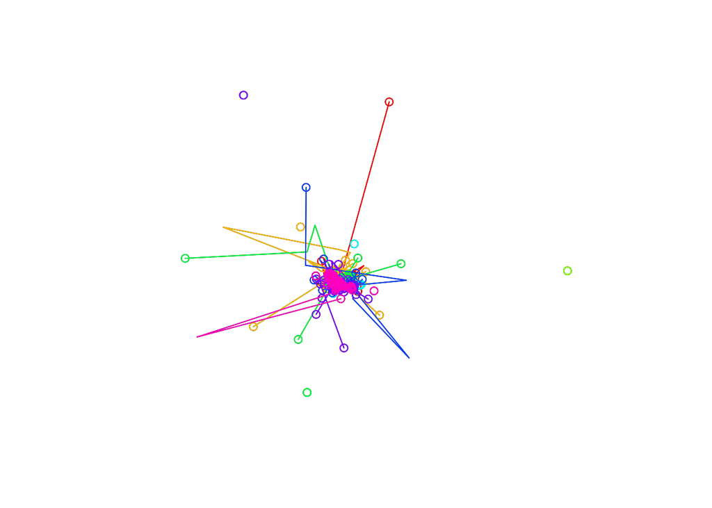

```r
plot(my_step)
```

You can also plot in ggplot, but right now its only using the geom_sftraj function. We can figure this out at a later date. But the method is very simple, you just have to tell geom_sf() what the grouping variable is.

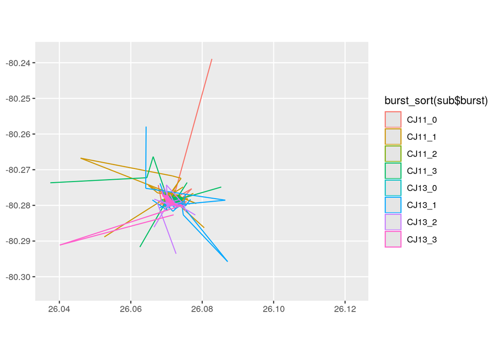

```r
library(ggplot2)
ggplot() + geom_sftraj(data = my_step)
```

## Bursts

Bursts are a big point in the class. They are made in a similar vain to the `sfc` and `sfg` in `sf`. `ind_burst` is a singular birst. Its whats stored at the row level. A `multi-burst` is a collection of `ind_bursts` and exists at the column level. Bursts also have an `active_burst` argument, which turns on and off certain bursts for analysis and plotting purposes.

```r
mb1 <- make_multi_burst(burst=burst, active_burst=c('id','month'))
str(mb1)
```

```
## multi_burst of length 3377; first list element: List of 3
##  $ id    : Factor w/ 2 levels "CJ11","CJ13": 1
##  $ month : Factor w/ 4 levels "0","1","2","3": 1
##  $ height: Factor w/ 2 levels "0","1": NA
##  - attr(*, "label")= chr "CJ11_0"
##  - attr(*, "active_burst")= chr [1:2] "id" "month"
##  - attr(*, "class")= chr "ind_burst"
```

Burst select allows you access to the active_burst

```r
burst_select(mb1)[1]
```

```
## [[1]]
## [[1]]$id
## [1] CJ11
## Levels: CJ11 CJ13
##
## [[1]]$month
## [1] 0
## Levels: 0 1 2 3
```

burst labels allows access to the burst labels which are a combination of the active bursts with ’_’ seperator

```r
burst_labels(mb1)[1:10]
```

```
##  [1] "CJ11_0" "CJ11_0" "CJ11_0" "CJ11_0" "CJ11_0" "CJ11_0" "CJ11_0"
##  [8] "CJ11_0" "CJ11_0" "CJ11_0"
```

Can combine multiple ind_bursts to create a multi_burst

```r
mb2 <- c(ind_burst(list(id = 1, year = 2018)),ind_burst(list(id = 2, year = 2018)))
str(mb2)
```

```
## multi_burst of length 2; first list element: List of 2
##  $ id  : Factor w/ 2 levels "1","2": 1
##  $ year: Factor w/ 1 level "2018": 1
##  - attr(*, "label")= chr "1_2018"
##  - attr(*, "active_burst")= chr [1:2] "id" "year"
##  - attr(*, "class")= chr "ind_burst"
```